# Lab 8: Comparing Two Population Means

kgteller

2023-06-04

# Lab 8: Comparing Two Population Means

Today we are going to look at conducting hypothesis tests when we have two samples of data. Recall the steps we want to take when running a hypothesis test:

1. A description the null and alternative hypotheses in terms of the problem.
2. A statement of the null and alternative hypotheses in standard symbols.
3. The significance level (size of the Type I error), α, that will be tolerated.
4. The name of the statistical test to be used and the assumptions required in order for the test to be valid. (i.e. small sample size, not approximately normal, paired, independent, etc.)
5. A clear description of exactly what the decision rule is; i.e. under what circumstances is the null hypothesis rejected.
6. A clear statement indicating whether or not you actually reject H0. This decision must be linked to the numerical value of p actually observed and the value of α.
7. A very clear description of what was actually decided in the context of the original problem. For example, if the problem is about mean airfares between two cities, simply saying reject Ho is not good enough; you need to say what this decision means as it applies to mean airfares.
8. Any statistical decision method is subject to Type I or Type II error. Discuss which type is possible in your final decision and if possible, its probability.

When we have two samples we need to first consider the relationship between the data. There are two different relationships we can have between the data:

**Independent Samples**: A random sample of size $n_1$ is selected from the first population, and a random sample of size $n_2$ is selected *independently* from the second population. The null hypothesis usually is $\mu_1=\mu_2$ .Then $\bar{x}_1-\bar{x}_2$is calculated, but this time a *2-sample test* is used; there is no way to view the data as a single sample.

When the sample sizes are small and the the both populations are not normal a Mann-Whitney test can sometimes be used. The Mann-Whitney test would be used if the two samples have a distribution with the same shape. in addition the Mann-Whitney test is not about $\mu_1$ and $\mu_2$, but about the population medians $\eta_1$ and $\eta_2$. so the two hypotheses become:

$H_0: \eta_1=\eta_2 \\$ $H_1: \eta_1 \neq,\lt,\gt \eta_2$

**Paired Samples** When the two samples have the same sample size and each data point in one sample can be *paired* with another data point in the other sample. The difference between the populations means is denoted $\mu_d=\mu_1-\mu_2$. Here the null hypothesis is that $\mu_d=0$. Now this can be treated as a single sample and a 1-sample hypothesis can br run on the **sample differences**.

In order to run either of these tests we can use the t.test(), or wilcox.test() commands that we discussed in the previous lab.

To run an independent 2-sample t-test we would use the following syntax: t.test(sample1,sample2)

to run an independent Mann-whitney test we would use the following syntax: wilcox.test(sample1,sample2,alternative=‘two.sided’,‘less’,‘greater’)

To run a paired t-test we use the following syntax: t.test(sample1,sample2,paired=TRUE)

for today’s lab we will data from the pulse.csv. The data relates to a class of statistic students that measured their resting pulse (Pulse1) and then a random number of students ran in place while the others just stayed still. The pulses of the entire class were recorded again (Pulse2). Along with the pulse data other data was collected that included, height, weight, sex, and weather or not they smoked.

For reference here is a more detailed summary of the data:

In this data set, there are 8 variables:

- Pulse1: The resting pulse of each student
- Pulse2: The pulse after running or not running for each student (after treatment)
- Ran: Whether or not the student ran in place: 1=Yes or 2=No (treatment)
- Smokes: Whether or not the student smokes regularly: 1=Yes or 2=No
- Sex: The biological characteristics of males or females of the student: 1=M or 2=F
- Height: The height of the student, in inches
- Weight: The weight of the student, in pounds
- Activity: The usual activity level of the student: 1=Slight, 2=Moderate, or 3=A lot

## Assignment 1

Recall Lab 0. Create the following objects to answer each of the other assignments:

| Name | Explanation of Name |
| --- | --- |
| Diffs | Pulse1-Pulse2 |
| Diffs_R | Pulse1 – Pulse2 for Runners (Ran = 1) |
| Diffs_NR | Pulse1 – Pulse2 for non Runners (Ran = 2) |
| Diffs_RandS | Pulse1 – Pulse 2 for Runners who smoke (Smokes = 1) |
| Diffs_RandNS | Pulse1 – Pulse2 for Runners who don’t smoke (Smokes = 2) |
| Weight_M | Weights of males |
| Weight_F | Weights of females |
| Weight_M_S | Weights of male smokers |
| Weight_M_NS | Weights of male non-smokers |
| Weight_F_S | Weights of female smokers |
| Weight_F_NS | Weights of female non-smoker |

```r
data0<-read.csv("Pulse.csv")

diffs <- data0$Pulse1-data0$Pulse2

r <- subset(data0, Ran == 1)
nr <- subset(data0, Ran == 2)
diffs_r <- r$Pulse1 - r$Pulse2

diffs_nr <- nr$Pulse1 - nr$Pulse2

s <- subset(data0, Smokes == 1)
ns <- subset(data0, Smokes == 2)

Diffs_RandS <- s$Pulse1 - s$Pulse2
Diffs_RandNS <- ns$Pulse1 - ns$Pulse2

Weight_M <- subset(data0, Sex == 1)$Weight

Weight_F <- subset(data0, Sex == 2)$Weight


Weight_M_S <- subset(subset(data0, Sex==1), Smokes == 1)$Weight

Weight_M_NS <- subset(subset(data0, Sex==1), Smokes == 2)$Weight

Weight_F_S <- subset(subset(data0, Sex==2), Smokes == 1)$Weight

Weight_F_NS <- subset(subset(data0, Sex==2), Smokes == 2)$Weight
```

**End Assignment 1**

## Assignment 2

A researcher wants to test the hypothesis that the average pulse of the class was greater the second time around than the first time. Conduct the appropriate test to test this hypothesis and clearly state your conclusion following the 8 steps described above.

```r
t.test(x=diffs, mu=0, alternative="less", conf.level=0.95)
```

```
##
##  One Sample t-test
##
## data:  diffs
## t = -5.0769, df = 91, p-value = 1.012e-06
## alternative hypothesis: true mean is less than 0
## 95 percent confidence interval:
##       -Inf -4.796501
## sample estimates:
## mean of x
## -7.130435
```

[output not shown]

**End Assignment 2**

Now it probably makes sense to separate the class into two groups, the runners and the non-runners.

## Assignment 3

A researcher now wants to look at the pulses of the running group before and after to conclude whether or not running in place increases mean heart rate. Conduct the appropriate test to test this hypothesis and clearly state your conclusion following the 8 steps described above.

```r
t.test(x=diffs_r, mu=0, alternative="less", conf.level=0.95)
```

```
##
##  One Sample t-test
##
## data:  diffs_r
## t = -7.4353, df = 34, p-value = 6.324e-09
## alternative hypothesis: true mean is less than 0
## 95 percent confidence interval:
##       -Inf -14.61281
## sample estimates:
## mean of x
## -18.91429
```

```
HA: mu pulse after running > mu pulse before running since they are paired take the difference to combine two samples into one:
diffs_r

H0: mu = 0
HA: mu < 0

HA becomes mu_diffs_R < 0
p-value = 6.324e-09
sample size of each greater than 30
sample sizen for Diffs is 35>30
sigma of diffs unknown

possible to be type 1 error

1-sample t should be used

In conclusion, The mean heart rate after running is greater.
```

**End Assignment 3**

## Assignment 4

A researcher now wants to run the same hypothesis as before but with the non-runners to see if there is any difference in mean heart rate. Conduct the appropriate test to test this hypothesis and clearly state your conclusion following the 8 steps described above.

```r
t.test(x=diffs_nr, mu=0, alternative="less", conf.level=0.95)
```

```
##
##  One Sample t-test
##
## data:  diffs_nr
## t = 0.19101, df = 56, p-value = 0.5754
## alternative hypothesis: true mean is less than 0
## 95 percent confidence interval:
##      -Inf 1.026953
## sample estimates:
## mean of x
## 0.1052632
```

```
HA: mu pulse after not running > mu pulse before not running
since they are paired take the difference to combine two samples into one:
Diffs_r

H0: mu = 0
HA: mu < 0
HA becomes mu_diffs_nr < 0
p-value = 0.5754 > 0.05
sample size of each greater than 30
sample sizen for diffs is 57>30
sigma of diffs unknown

1-sample t should be used

possible to be Type 2 error

In conclusion, the mean heart rate after not run does not have significant evidence to show that mu after running is greater
```

**End Assignment 4**

## Assignment 5

Now among the runners there could be another factor that affects the average heart rate. This confounding factor could be smoking. Therefore the researcher wants to know does the mean heart rate of smokers increase after running in place? Conduct the appropriate test to test this hypothesis and clearly state your conclusion following the 8 steps described above. You may have a small sample size and it is non-normal you may have to use the Wilcoxon or Sign tests discussed in the previous lab.

```r
#test for normality
ad.test(Diffs_RandS)
```

```
##
##  Anderson-Darling normality test
##
## data:  Diffs_RandS
## A = 0.70771, p-value = 0.05747
```

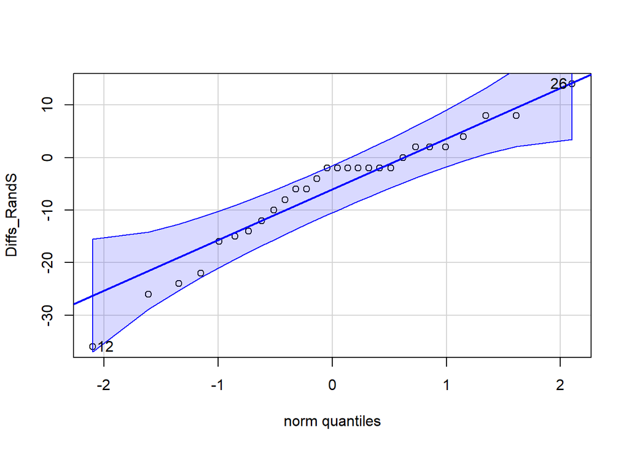

```
## [1] 12 26
```

```r
qqPlot(Diffs_RandS)
```

```r
t.test(x=Diffs_RandS, mu= 0, alternative = "less", conf.level=0.95)
```

```
##
##  One Sample t-test
##
## data:  Diffs_RandS
## t = -2.9066, df = 27, p-value = 0.003608
## alternative hypothesis: true mean is less than 0
## 95 percent confidence interval:
##       -Inf -2.557867
## sample estimates:
## mean of x
## -6.178571
```

[output not shown]

**End Assignment 5**

## Assignment 6

Now to make a comparison the next hypothesis would be does running in place increase the mean heart rate of non-smokers? Conduct the appropriate test to test this hypothesis and clearly state your conclusion following the 8 steps described above.

```r
#test for normality
ad.test(Diffs_RandNS)
```

```
##
##  Anderson-Darling normality test
##
## data:  Diffs_RandNS
## A = 6.2785, p-value = 1.35e-15
```

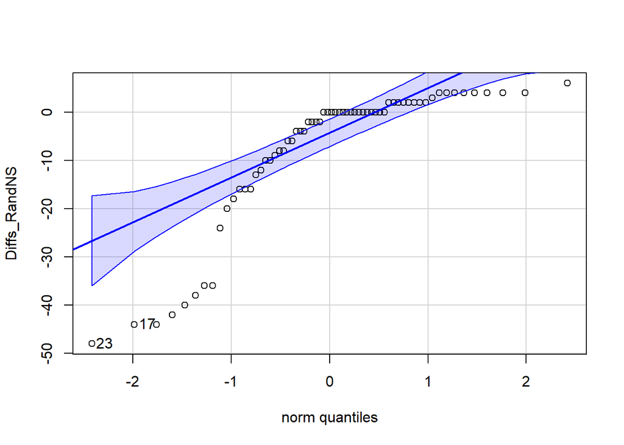

```
## [1] 23 17
```

```r
qqPlot(Diffs_RandNS)
```

```r
t.test(x=Diffs_RandNS, mu= 0, alternative = "less", conf.level=0.95)
```

```
##
##  One Sample t-test
##
## data:  Diffs_RandNS
## t = -4.193, df = 63, p-value = 4.381e-05
## alternative hypothesis: true mean is less than 0
## 95 percent confidence interval:
##      -Inf -4.54216
## sample estimates:
## mean of x
## -7.546875
```

[output not shown]

**End Assignment 6**

## Assignment 7

Now a researcher is interested in the weights of the class. They want to determine whether the weights of males and females differ.Conduct the appropriate test to test this hypothesis and clearly state your conclusion following the 8 steps described above. ( if using a non-parametric test remember to state the conclusion in terms of means and not medians)

```r
# since sd is not know of either we use 2 sample t test
t.test(x=Weight_M, y=Weight_F, mu = 0, alternative="two.sided", conf.level=0.95)
```

```
##
##  Welch Two Sample t-test
##
## data:  Weight_M and Weight_F
## t = 10.297, df = 87.713, p-value < 2.2e-16
## alternative hypothesis: true difference in means is not equal to 0
## 95 percent confidence interval:
##  27.81153 41.11479
## sample estimates:
## mean of x mean of y
##  158.2632  123.8000
```

```
** This sample is not paired**
n1 > 30 and n2 >30
HA: The weight of the females differs from the male

H0: mu = 0
HA: mu != 0
pvalue = 2.2e-16 < 0.05 = alpha
We can reject H0 and accept HA meaning
"The weight of the females differs from the males"
```

**End Assignment 7**

## Assignment 8

Going a little deeper into the data a researcher thinks that smoking might have an effect on weight. The researcher wants to test the hypothesis about whether the mean weight of males who smoke is different from males who do not smoke. Conduct the appropriate test to test this hypothesis and clearly state your conclusion following the 8 steps described above. ( if using a non-parametric test remember to state the conclusion in terms of means and not medians)

```r
Weight_M_S
```

```
##  [1] 160 190 160 153 175 170 180 185 170 150 145 155 180 130 155 150 140 190 150
## [20] 164
```

```r
Weight_M_NS
```

```
##  [1] 140 145 155 165 150 190 195 138 155 145 170 175 135 170 157 130 190 155 155
## [20] 215 155 155 150 150 160 135 160 148 155 150 180 145 140 142 136 123 155
```

```r
ad.test(Weight_M_S)
```

```
##
##  Anderson-Darling normality test
##
## data:  Weight_M_S
## A = 0.28138, p-value = 0.6017
```

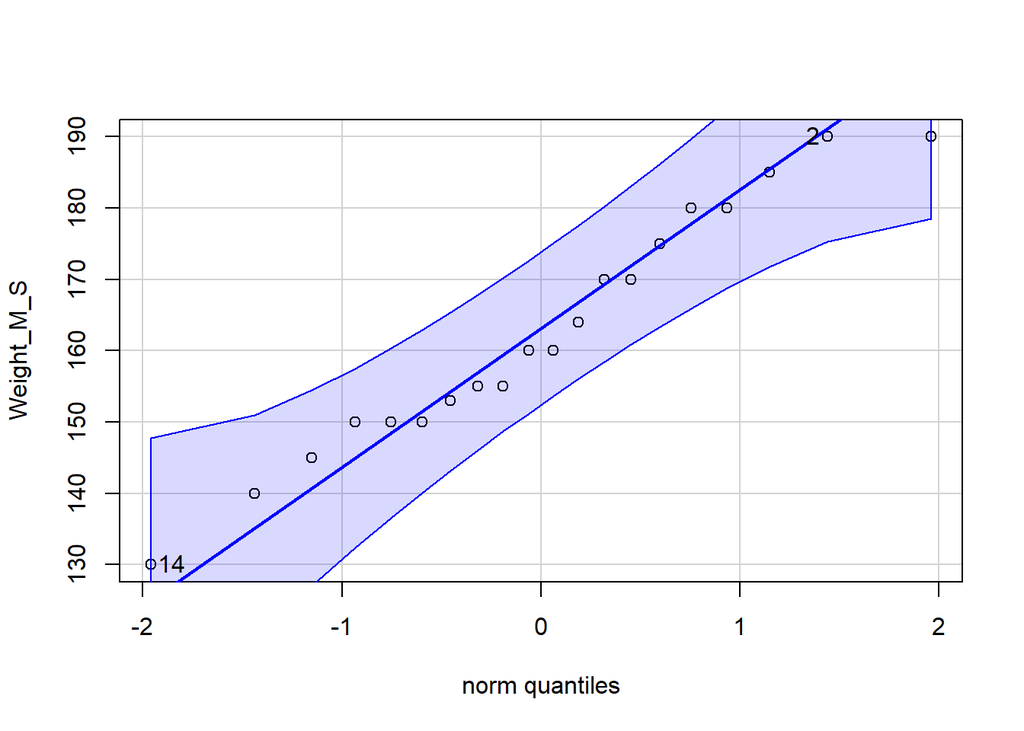

```
## [1] 14  2
```

```r
qqPlot(Weight_M_S)
```

```r
t.test(x=Weight_M_S, y=Weight_M_NS, mu=0, alternative="two.sided", conf.level=0.95)
```

```
##
##  Welch Two Sample t-test
##
## data:  Weight_M_S and Weight_M_NS
## t = 1.3518, df = 43.668, p-value = 0.1834
## alternative hypothesis: true difference in means is not equal to 0
## 95 percent confidence interval:
##  -3.281515 16.643677
## sample estimates:
## mean of x mean of y
##  162.6000  155.9189
```

```
This sample is not paired
n1 < 30 but n2 > 30
Weight_M_NS is normal from the n2 > 30
Weight_M_S needs ad.test and qqplot
ad test pvalue = 0.6017 > 0.05 so it is approximately normal
qq plot also shows normal
HA: The mean weight of males that smoke differs from the mean weight of non smoking men
H0: mu=0
HA: mu!=0
pvalue = 0.1834 > 0.05 so we fail reject H0 and fail to accept HA
Possibly Type 2 error
Fail to reject H0, Fail to accept HA
```

**End Assignment 8**

## Assignment 9

The last hypothesis that the researcher want to test is whether the mean weight of females who smoke is different from females who do not smoke. Conduct the appropriate test to test this hypothesis and clearly state your conclusion following the 8 steps described above. ( if using a non-parametric test remember to state the conclusion in terms of means and not medians)

```r
ad.test(Weight_F_NS)
```

```
##
##  Anderson-Darling normality test
##
## data:  Weight_F_NS
## A = 0.38221, p-value = 0.3744
```

```r
ad.test(Weight_F_S)
```

```
##
##  Anderson-Darling normality test
##
## data:  Weight_F_S
## A = 0.18386, p-value = 0.867
```

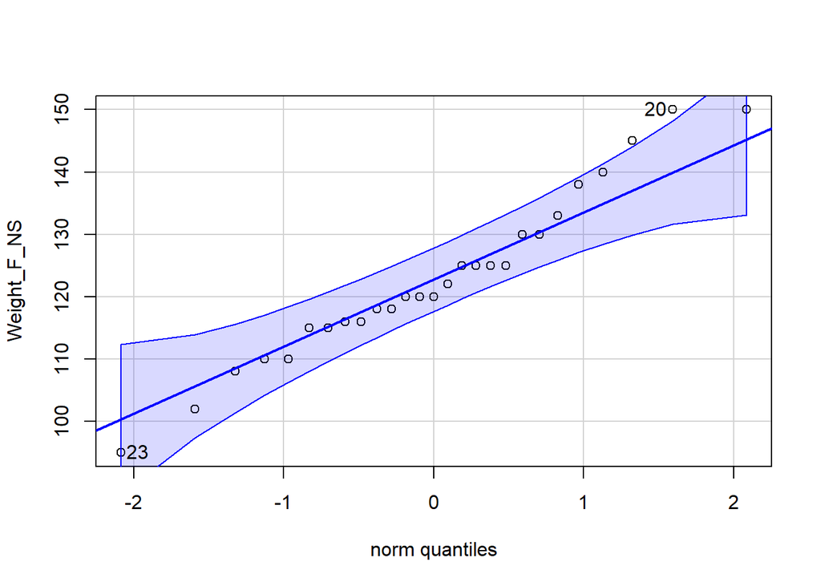

```
## [1] 23 20
```

```r
qqPlot(Weight_F_NS)
```

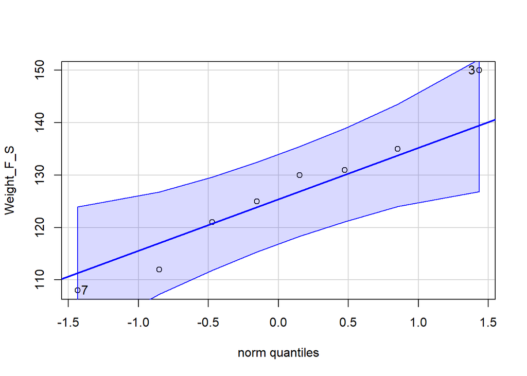

```
## [1] 3 7
```

```r
qqPlot(Weight_F_S)
```

```r
t.test(x=Weight_F_S, y=Weight_F_NS, mu=0, alternative="two.sided", conf.level=0.95)
```

```
##
##  Welch Two Sample t-test
##
## data:  Weight_F_S and Weight_F_NS
## t = 0.65036, df = 11.644, p-value = 0.5281
## alternative hypothesis: true difference in means is not equal to 0
## 95 percent confidence interval:
##  -8.265518 15.265518
## sample estimates:
## mean of x mean of y
##     126.5     123.0
```

```
not a paired sample
n1 and n2 <30
after ad test completion we find pvalues are both greater than 0.05 so these are normal samples
sds are not known so t.test needed
HA: The Weight of the females who smoke is different from the weights of the females who dont smoke
H0: mu= 0
HA: mu != 0
pvalue = 0.5281 > 0.05
So we will fail to reject H0 and fail to accept HA
Possible to be Type 2 error
```

**End Assignment 9**

## Conclusion assignment

Based on the hypotheses you have tested and there results write a concluding paragraph or more about your findings:

[output not shown]

**End Conclusion Assignment**